# 41Proj-Regression

Jiayi Yuan

2022-05-10

## Split data

```r
#install.packages("fastDummies")
library(fastDummies)
library(tidyr)
FPEDB = read.csv("FPEDB.csv")
FPEDB[FPEDB=="na"] <- NA
#colSums(is.na(FPEDB))

FPEDB_NEW <- FPEDB[,2:17] %>%
  na.omit()
for (i in 1:8){
  FPEDB_NEW[,i] <- sapply(FPEDB_NEW[,i], as.factor)
}
levels(FPEDB_NEW$P_T) <- c("A","A","C","C","M","M","N","N","T","T")
for(i in 14:16){
  FPEDB_NEW[,i] <- sapply(FPEDB_NEW[,i], as.factor)
}
for(i in 9:13){
  FPEDB_NEW[,i] <- sapply(FPEDB_NEW[,i], as.numeric)
}

set.seed(10)
train = sample(1:nrow(FPEDB_NEW),nrow(FPEDB_NEW)*0.5)
test = (-train)

FPEDB_REG <- FPEDB_NEW[,-c(2,3,5,6,7)]
### Deleted columns have too many different levels, and we don't want to analyze them

### Add dummy var
FPEDB_REG_Dummy <- dummy_cols(FPEDB_REG, select_columns = c('P_T', 'H_C',"GEO"),
           remove_selected_columns = TRUE)
FPEDB_REG_Dummy <- FPEDB_REG_Dummy[,-c(13,18,25)]
```

## Regression Tree

### MaxL

```r
library(MASS)
library(tree)
### we can only use factor predictors have at most 32 levels
# train.tree <- sample(1:nrow(FPEDB_tree),nrow(FPEDB_tree)*0.6)
# test.tree <- (-train.tree)
tree.dataM = tree(MaxL~., data = FPEDB_REG_Dummy, subset = train)
summary(tree.dataM)
```

```
##
## Regression tree:
## tree(formula = MaxL ~ ., data = FPEDB_REG_Dummy, subset = train)
## Variables actually used in tree construction:
## [1] "Y"                  "T"                  "GEO_AUS"
## [4] "H_C_Elasmobranchii" "B"                  "Ym"
## Number of terminal nodes:  14
## Residual mean deviance:  3147 = 38620000 / 12270
## Distribution of residuals:
##     Min.  1st Qu.   Median     Mean  3rd Qu.     Max.
## -512.000  -26.350   -9.347    0.000   16.650  827.500
```

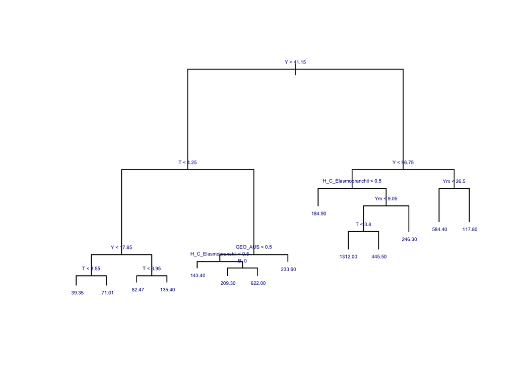

```r
### 6 variables chose, 14 nodes

### Without pruning
plot(tree.dataM)
text(tree.dataM,pretty = 0, cex = 0.4, col = "dark blue")
```

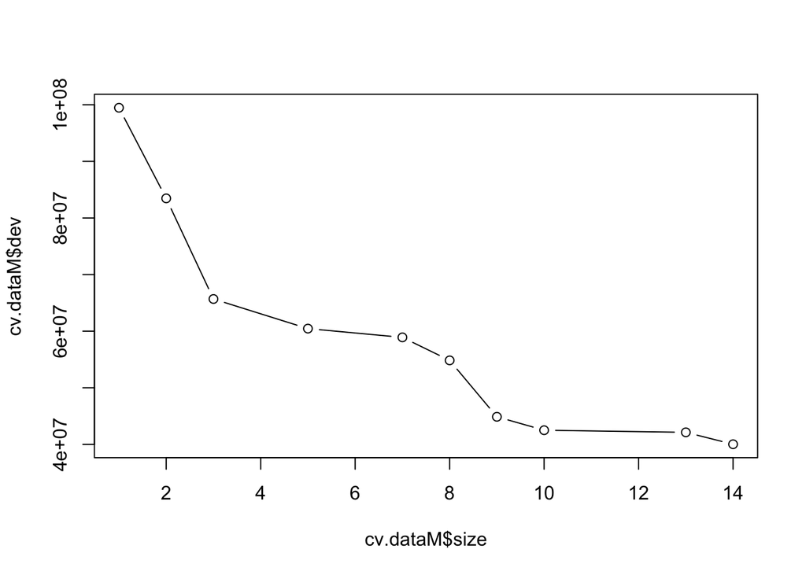

```r
### Eg: GEO_AUS<0.5 means Biogeographical region not Australia

### Pruning
#### Choose nodes first with cv
cv.dataM = cv.tree(tree.dataM, FUN = prune.tree)
plot(cv.dataM$size, cv.dataM$dev, type = "b")
```

```r
which.min(cv.dataM$dev)
```

```
## [1] 1
```

```r
### 14 nodes give the smallest cross-validation error, same as the tree without pruning.
### The most complex tree is chosen

###Pruning with 14 nodes
# prune.dataM = prune.tree(tree.dataM, best = 14)
# plot(prune.dataM)
# text(prune.dataM, pretty = 0, cex = 0.6)

### MSE without pruning (since with or without pruning are the same, they have same MSE as well)
tree.hatM = predict(tree.dataM, newdata = FPEDB_REG_Dummy[test,])
MaxL.test = FPEDB_REG_Dummy[test,"MaxL"]
(tree.MSE.M = mean((tree.hatM-MaxL.test)^2)) ####### MSE Larger than Lasso
```

```
## [1] 2997.741
```

```r
sqrt(tree.MSE.M)
```

```
## [1] 54.75163
```

```r
### MSE with pruning
# prune.hatM = predict(prune.dataM, newdata = FPEDB_tree[test,])
# prune.MSE.M = mean((prune.hatM - MaxL.test)^2)
# prune.MSE.M
# sqrt(prune.MSE.M)
#### Pruning doesn't make any improvements (no need to draw the and calculate the MSE actually)
```

CV chooses number of nodes same as that of the tree for training set. the test set MSE associated with the regression tree is 2997.741. The square root of the MSE is 54.75163, indicating that this model leads to test predictions that are within around 54.75163cm of the true maximum host body length. Interpreting: eg. the most left note, Y<41.15 yrs, T<4.25, Y<17.85yrs, T<3.55, Max length = 39.35cm.

### Y (Life Span)

```r
tree.dataY = tree(Y~., data = FPEDB_REG_Dummy, subset = train)
summary(tree.dataY)
```

```
##
## Regression tree:
## tree(formula = Y ~ ., data = FPEDB_REG_Dummy, subset = train)
## Variables actually used in tree construction:
## [1] "K"  "Ym"
## Number of terminal nodes:  7
## Residual mean deviance:  9.083 = 111600 / 12280
## Distribution of residuals:
##      Min.   1st Qu.    Median      Mean   3rd Qu.      Max.
## -19.47000  -2.17100  -0.07072   0.00000   2.18500  20.81000
```

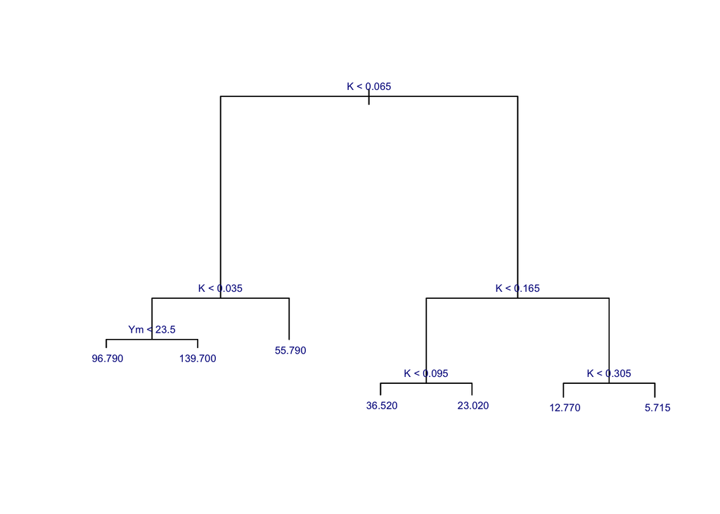

```r
### Only 2 variable chose, 7 nodes

### Without pruning
plot(tree.dataY)
text(tree.dataY,pretty = 0, cex = 0.6, col = "dark blue")
```

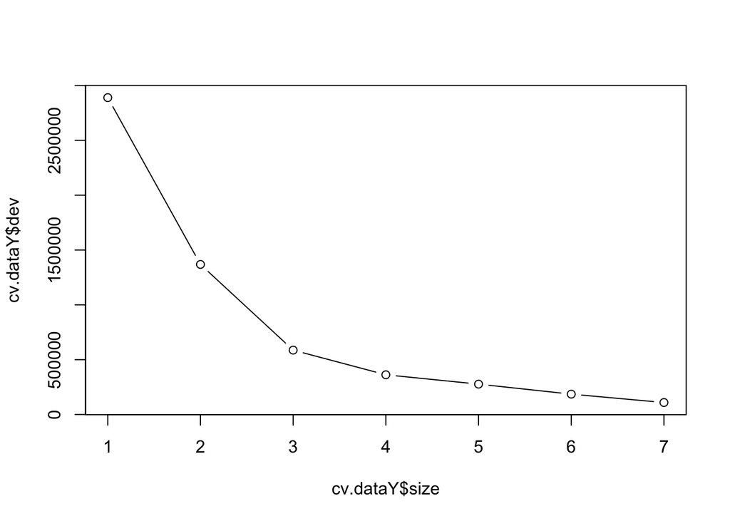

```r
### Pruning
#### Choose nodes first with cv
cv.dataY = cv.tree(tree.dataY)
plot(cv.dataY$size, cv.dataY$dev, type = "b")
```

```r
which.min(cv.dataY$dev)
```

```
## [1] 1
```

```r
### 7 nodes give the smallest cross-validation error, same

###Pruning with 7 nodes
# prune.dataY = prune.tree(tree.dataY, best = 7)
# plot(prune.dataY)
# text(prune.dataY, pretty = 0, cex = 0.6)

### MSE without pruning
tree.hatY = predict(tree.dataY, newdata = FPEDB_REG_Dummy[test,])
Y.test = FPEDB_REG_Dummy[test,"Y"]
(tree.MSE.Y = mean((tree.hatY-Y.test)^2))
```

```
## [1] 9.431635
```

```r
sqrt(tree.MSE.Y)
```

```
## [1] 3.071097
```

```r
### MSE with pruning
# prune.hatY = predict(prune.dataY, newdata = FPEDB_tree[test,])
# prune.MSE.Y = mean((prune.hatY - Y.test)^2)
# prune.MSE.Y
# sqrt(prune.MSE.Y)
```

CV chooses the most complex model, same as that without pruning. The test set MSE associated with the regression tree is 9.431635. The square root of the MSE is 3.071097, indicating that this model leads to test predictions that are within around 3.071097 years of the true host life span.

### T(Host Trophic Level)

```r
tree.dataT = tree(T~., data = FPEDB_REG_Dummy, subset = train)
summary(tree.dataT)
```

```
##
## Regression tree:
## tree(formula = T ~ ., data = FPEDB_REG_Dummy, subset = train)
## Variables actually used in tree construction:
## [1] "MaxL" "F"    "M"    "Ym"   "Y"
## Number of terminal nodes:  9
## Residual mean deviance:  0.2691 = 3304 / 12280
## Distribution of residuals:
##     Min.  1st Qu.   Median     Mean  3rd Qu.     Max.
## -2.15300 -0.24300  0.02141  0.00000  0.30100  1.32100
```

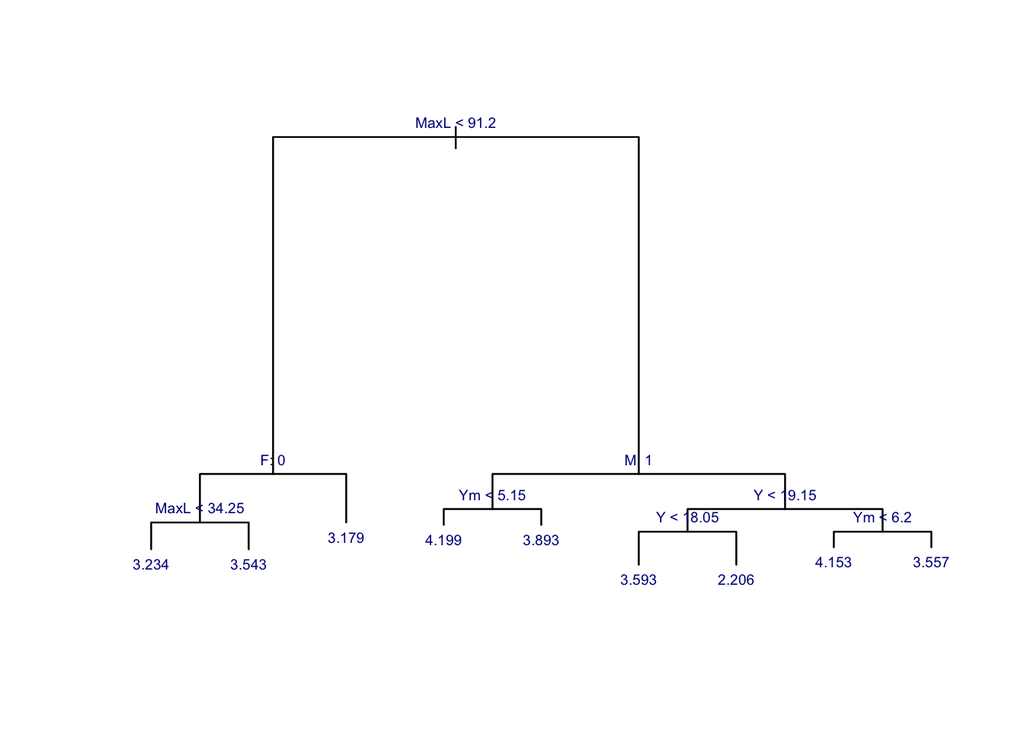

```r
### Only 5 variable chose, 9 nodes

### Without pruning
plot(tree.dataT)
text(tree.dataT,pretty = 0, cex = 0.6, col = "dark blue")
```

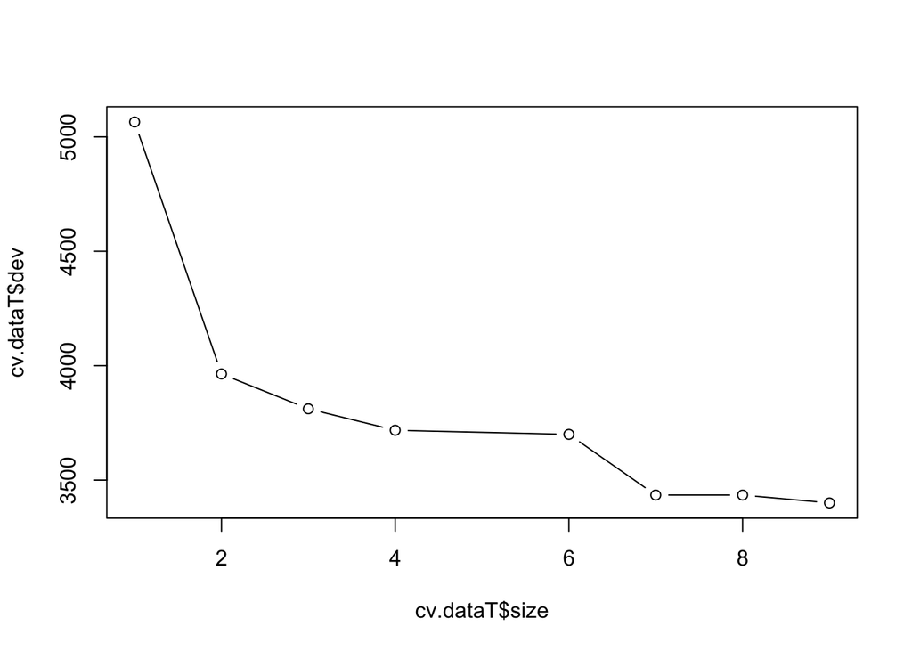

```r
### Pruning
#### Choose nodes first with cv
cv.dataT = cv.tree(tree.dataT)
plot(cv.dataT$size, cv.dataT$dev, type = "b")
```

```r
which.min(cv.dataT$dev)
```

```
## [1] 1
```

```r
### 9 nodes give the smallest cross-validation error, same

###Pruning with 5 nodes
# prune.dataT = prune.tree(tree.dataT, best = 5)
# plot(prune.dataT)
# text(prune.dataT, pretty = 0, cex = 0.6)

### MSE without pruning
tree.hatT = predict(tree.dataT, newdata = FPEDB_REG_Dummy[test,])
T.test = FPEDB_REG_Dummy[test,"T"]
(tree.MSE.T = mean((tree.hatT-T.test)^2))
```

```
## [1] 0.2718997
```

```r
sqrt(tree.MSE.T)
```

```
## [1] 0.52144
```

```r
### MSE with pruning
# prune.hatT = predict(prune.dataT, newdata = FPEDB_REG_Dummy[test,])
# prune.MSE.T = mean((prune.hatT - T.test)^2)
# prune.MSE.T
# sqrt(prune.MSE.T)
```